# How well weight lifting exercises are done by people?

Piotr Tomasz Piotrowski

## Executive Summary

This report was written for purposes of Peer-graded Assignment: “Prediction Assignment Writeup”, contained in “Practical Machine Learning” Coursera Course. The report answers to general research question “How well weight lifting exercises are done by people? through processing data from sports devices accelerometers, located: on the belt, forearm, arm, and dumbell, of 6 participants. The data were processed using two kinds of machine learning algorithms, that is: Random Forest and Recursive Partitioning and Regression Trees. Model selection, Features selection, Cross validation, calculations of out of sample errors and final prediction related to quality of weight lifting exercising were performed for both two models. Model using Random Forest algorithm offers smaller prediction errors and bigger fitting accuracy for used datasets. Final prediction results are available in last part of this work.

## Load training and test data

```r
if(!file.exists("./pml-training.csv")){
  download.file(url = "https://d396qusza40orc.cloudfront.net/predmachlearn/pml-training.csv", destfile = "pml-training.csv")
}
if(!file.exists("./pml-testing.csv")){
  download.file(url = "https://d396qusza40orc.cloudfront.net/predmachlearn/pml-testing.csv", destfile = "pml-testing.csv")
}
training <- read.csv(file = "./pml-training.csv")
str(training, list.len = 15)
```

```
## 'data.frame':    19622 obs. of  160 variables:
##  $ X                       : int  1 2 3 4 5 6 7 8 9 10 ...
##  $ user_name               : Factor w/ 6 levels "adelmo","carlitos",..: 2 2 2 2 2 2 2 2 2 2 ...
##  $ raw_timestamp_part_1    : int  1323084231 1323084231 1323084231 1323084232 1323084232 1323084232 1323084232 1323084232 1323084232 1323084232 ...
##  $ raw_timestamp_part_2    : int  788290 808298 820366 120339 196328 304277 368296 440390 484323 484434 ...
##  $ cvtd_timestamp          : Factor w/ 20 levels "02/12/2011 13:32",..: 9 9 9 9 9 9 9 9 9 9 ...
##  $ new_window              : Factor w/ 2 levels "no","yes": 1 1 1 1 1 1 1 1 1 1 ...
##  $ num_window              : int  11 11 11 12 12 12 12 12 12 12 ...
##  $ roll_belt               : num  1.41 1.41 1.42 1.48 1.48 1.45 1.42 1.42 1.43 1.45 ...
##  $ pitch_belt              : num  8.07 8.07 8.07 8.05 8.07 8.06 8.09 8.13 8.16 8.17 ...
##  $ yaw_belt                : num  -94.4 -94.4 -94.4 -94.4 -94.4 -94.4 -94.4 -94.4 -94.4 -94.4 ...
##  $ total_accel_belt        : int  3 3 3 3 3 3 3 3 3 3 ...
##  $ kurtosis_roll_belt      : Factor w/ 397 levels "","-0.016850",..: 1 1 1 1 1 1 1 1 1 1 ...
##  $ kurtosis_picth_belt     : Factor w/ 317 levels "","-0.021887",..: 1 1 1 1 1 1 1 1 1 1 ...
##  $ kurtosis_yaw_belt       : Factor w/ 2 levels "","#DIV/0!": 1 1 1 1 1 1 1 1 1 1 ...
##  $ skewness_roll_belt      : Factor w/ 395 levels "","-0.003095",..: 1 1 1 1 1 1 1 1 1 1 ...
##   [list output truncated]
```

```r
testing <- read.csv(file = "./pml-testing.csv")
str(testing, list.len = 15)
```

```
## 'data.frame':    20 obs. of  160 variables:
##  $ X                       : int  1 2 3 4 5 6 7 8 9 10 ...
##  $ user_name               : Factor w/ 6 levels "adelmo","carlitos",..: 6 5 5 1 4 5 5 5 2 3 ...
##  $ raw_timestamp_part_1    : int  1323095002 1322673067 1322673075 1322832789 1322489635 1322673149 1322673128 1322673076 1323084240 1322837822 ...
##  $ raw_timestamp_part_2    : int  868349 778725 342967 560311 814776 510661 766645 54671 916313 384285 ...
##  $ cvtd_timestamp          : Factor w/ 11 levels "02/12/2011 13:33",..: 5 10 10 1 6 11 11 10 3 2 ...
##  $ new_window              : Factor w/ 1 level "no": 1 1 1 1 1 1 1 1 1 1 ...
##  $ num_window              : int  74 431 439 194 235 504 485 440 323 664 ...
##  $ roll_belt               : num  123 1.02 0.87 125 1.35 -5.92 1.2 0.43 0.93 114 ...
##  $ pitch_belt              : num  27 4.87 1.82 -41.6 3.33 1.59 4.44 4.15 6.72 22.4 ...
##  $ yaw_belt                : num  -4.75 -88.9 -88.5 162 -88.6 -87.7 -87.3 -88.5 -93.7 -13.1 ...
##  $ total_accel_belt        : int  20 4 5 17 3 4 4 4 4 18 ...
##  $ kurtosis_roll_belt      : logi  NA NA NA NA NA NA ...
##  $ kurtosis_picth_belt     : logi  NA NA NA NA NA NA ...
##  $ kurtosis_yaw_belt       : logi  NA NA NA NA NA NA ...
##  $ skewness_roll_belt      : logi  NA NA NA NA NA NA ...
##   [list output truncated]
```

## Data analysis and cleaning

Remove variables not related to accelerometers, that is related to: row number, user, time, windows, gyroscope and magnetometer:

```r
training <- training[ ,-(1:7)]
testing <- testing[ ,-(1:7)]
gyrosMagnetVariables <- grep(pattern = "gyros|magnet", x = colnames(training))
training <- training[, -gyrosMagnetVariables]
testing <- testing[, -gyrosMagnetVariables]
```

There are variables, which have NAs in all rows in testing data. Such variables will be removed from testing data, because they do not contain information. The same variables, like excluded in testing data, will be removed also from training data. These variables contain NAs or NULLs for almost all rows, so information lost is marginal:

```r
naColumnsTesting <- colnames(testing[,colSums(is.na(testing)) == nrow(testing)])
testing <- testing[,colSums(is.na(testing)) != nrow(testing)]
training <- training[ , !(colnames(training) %in% naColumnsTesting)]
```

After above operations both testing data and training data do not contain: NAs, NULLs and “#DIV/0!” values.

## Split training set to new training set and test set for cross validation of model related to Random Forest algorithm

```r
library("caret")
library("e1071")
inTrain <- createDataPartition(y = training$classe, p = 0.75, list = FALSE)
trainingCV <- training[inTrain, ]
dim(trainingCV)
```

```
## [1] 14718    29
```

```r
testingCV <- training[-inTrain, ]
dim(testingCV)
```

```
## [1] 4904   29
```

## Model fitting using Breiman’s Random Forest algorithm

Model fitting using Breiman’s Random Forest algorithm is performed using randomForest function. Random Forest algorithm was used in the report, because such algorithm was successfully applied in earlier work [VBGUF13]. randomForest function was chosen as fast alternative of train function (with method = “rf”):

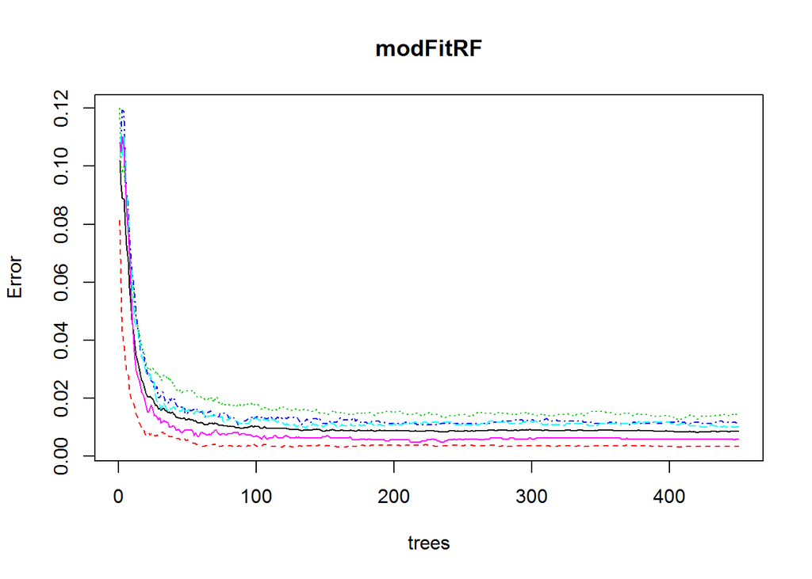

```r
library("randomForest")
modFitRF <- randomForest(classe ~., data = trainingCV, ntree = 450)
plot(modFitRF)
```

The best model fitting was achieved when:  
- the most correlated variables were not removed from training set,  
- number of trees is higher.

## Feature selection - remove highly correlated variables to better perform modelling using Recursive Partitioning and Regression Trees algorithm

```r
correlationMatrix <- cor(subset(training, select = -c(classe)))
highlyCorrelated <- findCorrelation(correlationMatrix, cutoff = 0.9)
trainingWoCorrVars <- training[,-c(as.vector(highlyCorrelated))]
dim(trainingWoCorrVars)
```

```
## [1] 19622    25
```

## Split training set to new training set and test set for cross validation of model related to Recursive Partitioning and Regression Trees algorithm

```r
inTrainWoCorrVars <- createDataPartition(y = trainingWoCorrVars$classe, p = 0.75, list = FALSE)
trainingCVWoCorrVars <- trainingWoCorrVars[inTrain, ]
dim(trainingCVWoCorrVars)
```

```
## [1] 14718    25
```

```r
testingCVWoCorrVars <- trainingWoCorrVars[-inTrain, ]
dim(testingCVWoCorrVars)
```

```
## [1] 4904   25
```

## Model fitting using Recursive Partitioning and Regression Trees algorithm algorithm

Model fitting using Recursive Partitioning and Regression Trees algorithm was also used in this report in order to make results comparison with Random Forest algorithm. Secondly, train function with “rpart” method working fast and gives consistent outputs format with Random Forest results.

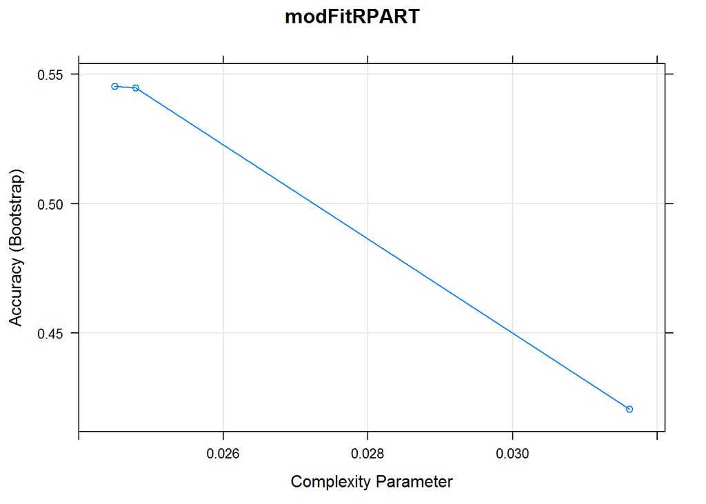

```r
modFitRPART <- train(classe ~., data = trainingCVWoCorrVars, method = "rpart")
plot(modFitRPART, main = "modFitRPART")
```

## Prediction on testing set and Confusion Matrix used for cross validation for both models

```r
predRFCV <- predict(modFitRF, testingCV)
confusionMatrix(testingCV$classe, predRFCV)
```

```
## Confusion Matrix and Statistics
##
##           Reference
## Prediction    A    B    C    D    E
##          A 1393    2    0    0    0
##          B   10  936    3    0    0
##          C    2    6  843    4    0
##          D    0    0    5  799    0
##          E    0    1    0    1  899
##
## Overall Statistics
##
##                Accuracy : 0.9931
##                  95% CI : (0.9903, 0.9952)
##     No Information Rate : 0.2865
##     P-Value [Acc > NIR] : < 2.2e-16
##
##                   Kappa : 0.9912
##  Mcnemar's Test P-Value : NA
##
## Statistics by Class:
##
##                      Class: A Class: B Class: C Class: D Class: E
## Sensitivity            0.9915   0.9905   0.9906   0.9938   1.0000
## Specificity            0.9994   0.9967   0.9970   0.9988   0.9995
## Pos Pred Value         0.9986   0.9863   0.9860   0.9938   0.9978
## Neg Pred Value         0.9966   0.9977   0.9980   0.9988   1.0000
## Prevalence             0.2865   0.1927   0.1735   0.1639   0.1833
## Detection Rate         0.2841   0.1909   0.1719   0.1629   0.1833
## Detection Prevalence   0.2845   0.1935   0.1743   0.1639   0.1837
## Balanced Accuracy      0.9954   0.9936   0.9938   0.9963   0.9998
```

```r
predRPARTCV <- predict(modFitRPART, testingCVWoCorrVars)
confusionMatrix(testingCVWoCorrVars$classe, predRPARTCV)
```

```
## Confusion Matrix and Statistics
##
##           Reference
## Prediction   A   B   C   D   E
##          A 963 110 235  61  26
##          B 230 309 248  51 111
##          C  32 116 697  10   0
##          D 164  46 244 331  19
##          E  86 113 269  52 381
##
## Overall Statistics
##
##                Accuracy : 0.5467
##                  95% CI : (0.5326, 0.5607)
##     No Information Rate : 0.3452
##     P-Value [Acc > NIR] : < 2.2e-16
##
##                   Kappa : 0.4261
##  Mcnemar's Test P-Value : < 2.2e-16
##
## Statistics by Class:
##
##                      Class: A Class: B Class: C Class: D Class: E
## Sensitivity            0.6529  0.44524   0.4117   0.6554  0.70950
## Specificity            0.8740  0.84798   0.9508   0.8925  0.88093
## Pos Pred Value         0.6903  0.32561   0.8152   0.4117  0.42286
## Neg Pred Value         0.8541  0.90265   0.7540   0.9576  0.96103
## Prevalence             0.3008  0.14152   0.3452   0.1030  0.10950
## Detection Rate         0.1964  0.06301   0.1421   0.0675  0.07769
## Detection Prevalence   0.2845  0.19352   0.1743   0.1639  0.18373
## Balanced Accuracy      0.7634  0.64661   0.6812   0.7740  0.79521
```

## Out of sample errors as mean square errors and root mean square errors for both algorithms

```r
library("ModelMetrics")
mseRF <- mse(testingCV$classe, predRFCV)
mseRPART <- mse(testingCVWoCorrVars$classe, predRPARTCV)
rmseRF <- rmse(testingCV$classe, predRFCV)
rmseRPART <- rmse(testingCVWoCorrVars$classe, predRPARTCV)
detach("package:ModelMetrics")
```

### Results summary for both algorithms

```r
accuracyRF <- as.numeric(confusionMatrix(testingCV$classe, predRFCV)$overall['Accuracy'])
accuracyRPART <- as.numeric(confusionMatrix(testingCV$classe, predRPARTCV)$overall['Accuracy'])
modelPropertyName <- c("Accuracy", "MSE", "RMSE")
randomForest <- c(accuracyRF, mseRF, rmseRF)
regressionTrees <- c(accuracyRPART, mseRPART, rmseRPART)
data.frame(modelPropertyName, randomForest, regressionTrees)
```

```
##   modelPropertyName randomForest regressionTrees
## 1          Accuracy  0.993066884       0.5466966
## 2               MSE  0.009787928       1.9155791
## 3              RMSE  0.098933959       1.3840445
```

Model using Random Forest algorithm has smaller prediction errors and higher accuracy.

## Prediction of 20 different test cases for both algorithms

```r
predRF <- predict(modFitRF, testing[ ,-29])
table(predRF, testing$problem_id)
```

```
##
## predRF 1 2 3 4 5 6 7 8 9 10 11 12 13 14 15 16 17 18 19 20
##      A 0 1 0 1 1 0 0 0 1  1  0  0  0  1  0  0  1  0  0  0
##      B 1 0 1 0 0 0 0 1 0  0  1  0  1  0  0  0  0  1  1  1
##      C 0 0 0 0 0 0 0 0 0  0  0  1  0  0  0  0  0  0  0  0
##      D 0 0 0 0 0 0 1 0 0  0  0  0  0  0  0  0  0  0  0  0
##      E 0 0 0 0 0 1 0 0 0  0  0  0  0  0  1  1  0  0  0  0
```

```r
predRPART <- predict(modFitRPART, testing[ ,-29])
table(predRPART, testing$problem_id)
```

```
##
## predRPART 1 2 3 4 5 6 7 8 9 10 11 12 13 14 15 16 17 18 19 20
##         A 0 0 0 0 0 0 0 0 1  1  0  0  0  1  0  1  0  0  1  0
##         B 0 0 0 0 0 1 0 0 0  0  1  0  0  0  0  0  0  0  0  0
##         C 1 1 1 1 1 0 1 0 0  0  0  1  1  0  1  0  0  0  0  1
##         D 0 0 0 0 0 0 0 1 0  0  0  0  0  0  0  0  0  1  0  0
##         E 0 0 0 0 0 0 0 0 0  0  0  0  0  0  0  0  1  0  0  0
```

## References

[VBGUF13] Velloso, E.; Bulling, A.; Gellersen, H.; Ugulino, W.; Fuks, H. [Qualitative Activity Recognition of Weight Lifting Exercises.](http://web.archive.org/web/20161224072740/http://groupware.les.inf.puc-rio.br/public/papers/2013.Velloso.QAR-WLE.pdf) Proceedings of 4th International Conference in Cooperation with SIGCHI (Augmented Human ’13) . Stuttgart, Germany: ACM SIGCHI, 2013.